# When to Stop Pulling?

Do Won Kim

2023-08-30

# Overview

For each individual user, when is it that we see all the low-quality friends for the first time?

- Make a column of each individual users (length = 21)
- Another column would be the # of tweets since data collection when each individual user reached the target point
- So as each user’s tweets from home timeline is collected, we see the tweets produced by low-quality friends - and at the some point, all the low-quality friends of each user would appear in the accumulated tweets collected. Find that point and extract the # of tweets.
- Details:
  1. Filter those who follow low-quality accounts
  2. Arrange the data by `user_id` and `tweet_timestamp`
  3. For each user, make a new variable that indicates the accumulated number of distinct low quality friends appeared in the tweets collected
  4. For each user, filter only the row that indicates the threshold - where the new variable created in step 3 does not anymore increase
  5. Make a data frame with 21 users with columns: `user_id` column, and `# of tweets collected`
  6. Draw plot

```r
# Load packages
library(readr)
library(tidyverse)
library(ggplot2)
library(ggthemes)
library(grid)
library(gridExtra)
library(scales)
library(rempsyc)
library(report)
library(broom)
library(gapminder)
library(DT)
library(dplyr)
library(magrittr)
library(ggstatsplot)
library(barcode)
library(gghalves)
library(ggdist)
```

```r
# Load the data
df <- read_csv("df.csv")

# Define data type
df |>
  mutate(
    user_id = as.factor(user_id),
    tweet_id = as.factor(tweet_id),
    friend_id = as.factor(account_id)
  ) |>
  dplyr::select(-account_id) -> df

# Timestamp data of each tweet: tweet_timestamp
list_timestamp <- str_split(df$tweet_timestamp, " ")  # make a list containing each string component of timestamp data

Month = c()  # make an empty vector
Day = c()
Time = c()
Year = c()
timestamp_dmyt = c()

# fill these vectors with month, day, time, year components within each list element
for (i in 1:length(list_timestamp)) {
  list_timestamp[[i]][2] -> Month[i]
  list_timestamp[[i]][3] -> Day[i]
  list_timestamp[[i]][4] -> Time[i]
  list_timestamp[[i]][6] -> Year[i]
  }

timestamp_dmyt = as.data.frame(cbind(Day, Month, Year, Time)) # bind these filled vectors and make it as a dataframe; store this dataframe as 'timestamp_dmyt'

# now paste the strings into one and store them in a vector 'dmyt'
dmyt = c()
for (i in 1:nrow(timestamp_dmyt)) {
  dmyt[i] = paste(Day[i], Month[i], Year[i], Time[i])
}

# make 'dmyt' vector as a new variable of dataframe: 'tweet_timestamp'
df$tweet_timestamp = dmy_hms(dmyt)  # timestamp format: day-month-year-hour-minute-second
#* Note:
#* This is a sample code for merging low quality twitter accounts from different data sources
#* Here, I combine low quality sources from (1) FIBER lists, (2) NewsGuard lists

# (1) FIBER
# Load all the FIB twitter lists
X2022_01_fib_indices_twitter <- read_csv("list/2022_01__fib_indices_twitter.csv")
X2022_02_fib_indices_twitter <- read_csv("list/2022_02__fib_indices_twitter.csv")
X2022_03_fib_indices_twitter <- read_csv("list/2022_03__fib_indices_twitter.csv")
X2022_04_fib_indices_twitter <- read_csv("list/2022_04__fib_indices_twitter.csv")
X2022_05_fib_indices_twitter <- read_csv("list/2022_05__fib_indices_twitter.csv")
X2022_06_fib_indices_twitter <- read_csv("list/2022_06__fib_indices_twitter.csv")
X2022_07_fib_indices_twitter <- read_csv("list/2022_07__fib_indices_twitter.csv")
X2022_08_fib_indices_twitter <- read_csv("list/2022_08__fib_indices_twitter.csv")
X2022_09_fib_indices_twitter <- read_csv("list/2022_09__fib_indices_twitter.csv")
X2022_10_fib_indices_twitter <- read_csv("list/2022_10__fib_indices_twitter.csv")
X2022_11_fib_indices_twitter <- read_csv("list/2022_11__fib_indices_twitter.csv")
X2022_12_fib_indices_twitter <- read_csv("list/2022_12__fib_indices_twitter.csv")
X2023_01_fib_indices_twitter <- read_csv("list/2023_01__fib_indices_twitter.csv")
X2023_02_fib_indices_twitter <- read_csv("list/2023_02__fib_indices_twitter.csv")
X2023_03_fib_indices_twitter <- read_csv("list/2023_03__fib_indices_twitter.csv")
X2023_04_fib_indices_twitter <- read_csv("list/2023_04__fib_indices_twitter.csv")
X2023_05_fib_indices_twitter <- read_csv("list/2023_05__fib_indices_twitter.csv")
X2023_06_fib_indices_twitter <- read_csv("list/2023_06__fib_indices_twitter.csv")

# Merge and de-duplicate the list
unique_list <- rbind(X2022_01_fib_indices_twitter, X2022_02_fib_indices_twitter, X2022_03_fib_indices_twitter,
                     X2022_04_fib_indices_twitter, X2022_05_fib_indices_twitter, X2022_06_fib_indices_twitter,
                     X2022_07_fib_indices_twitter, X2022_08_fib_indices_twitter, X2022_09_fib_indices_twitter,
                     X2022_10_fib_indices_twitter, X2022_11_fib_indices_twitter, X2022_12_fib_indices_twitter,
                     X2023_01_fib_indices_twitter, X2023_02_fib_indices_twitter, X2023_03_fib_indices_twitter,
                     X2023_04_fib_indices_twitter, X2023_05_fib_indices_twitter, X2023_06_fib_indices_twitter) |>
  dplyr::select(user_id, username) |>
  mutate(user_id = as.factor(user_id)) |>
  unique()

# Check the list: 155 unique users identified
# glimpse(unique_list)

# Make a new dataframe: fiber
unique_list |>
  dplyr::select(username) |>
  rename(screen_name = username) -> fiber

# (2) NewsGuard
# Load recent metadata csv file
metadata1 <- read_csv("metadata-2023063000.csv")
metadata2 <- read_csv("metadata-2023063001.csv")
metadata3 <- read_csv("metadata-2023063004.csv")
metadata4 <- read_csv("metadata-2023063006.csv")
metadata5 <- read_csv("metadata-2023063009.csv")
metadata6 <- read_csv("metadata-2023063011.csv")
metadata7 <- read_csv("metadata-2023063014.csv")
metadata8 <- read_csv("metadata-2023063017.csv")
metadata9 <- read_csv("metadata-2023063020.csv")
metadata10 <- read_csv("metadata-2023063023.csv")

# Filter only those twitter accounts with ratings "N" (low score)
rbind(metadata1, metadata2, metadata3, metadata4, metadata5,
      metadata6, metadata7, metadata8, metadata9, metadata10) |>
  dplyr::select(Rating, Twitter) |>
  na.omit() |>
  filter(Rating == "N") -> metadata

# glimpse(metadata)

# Split the twitter link by '/'
list_str = str_split(unique(metadata$Twitter), "/")

# Let's clean the strings to keep only the 'handle'
list_handle = c()
for (i in 1:length(list_str)) {
  list_handle[i] = list_str[[i]][4]
}

list_str = str_split(list_handle, "\\?")
list_handle = c()
for (i in 1:length(list_str)) {
  list_handle[i] = list_str[[i]][1]
}

list_str = str_split(list_handle, "\\,")
list_handle = c()
for (i in 1:length(list_str)) {
  list_handle[i] = list_str[[i]][1]
}

# Make a new dataframe: newsguard
newsguard = data.frame(screen_name = list_handle)

# Combine these two dataframes and de-duplicate
low_quality = rbind(newsguard, fiber) |> unique()

# Make a new column indicating that these sources are low quality sources
low_quality |>
  mutate(low_quality = "yes") -> low_quality

# Merge the low quality sources to the dataframe
df |>
  left_join(low_quality, by="screen_name") -> df2

# Filter only those who follow low-quality sources (21 users)
df2 |>
  group_by(user_id) |>
  dplyr::select(low_quality) |>
  unique() |>
  filter(low_quality == "yes") |>
  rename(filter = low_quality) -> for_filter

df2 |>
  left_join(for_filter, by="user_id") |>
  filter(filter == "yes") |>
  select(-filter) -> df3

# Dataframe `df3` contains only 21 users that we are interested in.

df3 |>
  arrange(user_id, tweet_timestamp) |> # Arrange the data by user_id and tweet_timestamp
  group_by(user_id) |>
  count(tweet_id) |>
  mutate(x = cumsum(n)) |>  # x = # of tweets collected so far by each user
  dplyr::select(user_id, tweet_id, x) -> df_for_x

df3 |>
  left_join(df_for_x, by=c("user_id", "tweet_id")) -> df3


df3 |>
  filter(!is.na(low_quality)) |> # Filter only the rows with friend account is low-quality
  arrange(user_id, tweet_timestamp) |>  # Arrange the data
  group_by(user_id) |>  # For each user,
  mutate(low_quality_count = cumsum(!duplicated(screen_name))) |>  # Make a new variable `low_quality_count` that indicates the accumulated number of distinct low quality friends appeared in the tweets collected
  mutate(max_lowq_count = max(low_quality_count)) |>  # Make another variable that indicates the maximum number of distinct low quality friends
  filter(low_quality_count == max_lowq_count) |> # Filter only the rows that matches the following condition: maximum # of low quality friends == accumulated # of distinct low quality friends (this is the threshold)
  mutate(tick = min(tweet_timestamp)) |>
  filter(tick == tweet_timestamp) |>  # among the rows with the same threshold, filter those with the minimum tweet_timestamp value (this is when each user reached the threshold first time)
  select(user_id, tweet_id, x, low_quality_count) |>  # select user_id, tweet_id, x (=# of tweets collecetd per user), and low_quality_count (total # of low quality friends seen) at the threshold
  ungroup() -> df4

# In `df4`, user_id = "243031077" appears twice due to the fact that two low quality sources tweeted at the same time -> we keep only the row with high x value

df4 = df4[-10,-2]
```

At the threshold, the data looks like the table below:

```r
df4 |>
  rename(`User ID` = user_id,
         `# of Tweets` = x,
         `Total # of low quality friends` = low_quality_count) -> df4_dtable

datatable(df4_dtable, caption = "Number of Tweets collected at the threshold per user")
```

|  | User ID | # of Tweets | Total # of low quality friends |
| --- | --- | --- | --- |
| 1 | 774771 | 1 | 1 |
| 2 | 20406464 | 14177 | 4 |
| 3 | 46722063 | 567 | 2 |
| 4 | 59574803 | 143 | 1 |
| 5 | 86237732 | 12 | 1 |
| 6 | 128489802 | 351 | 1 |
| 7 | 133806693 | 12246 | 3 |
| 8 | 150097462 | 264 | 1 |
| 9 | 243031077 | 439 | 2 |
| 10 | 360661169 | 3882 | 2 |

[output cut: 11 more lines]

Based on the `# of Tweets` (=x) in this data frame, let’s draw density & barcode plot.

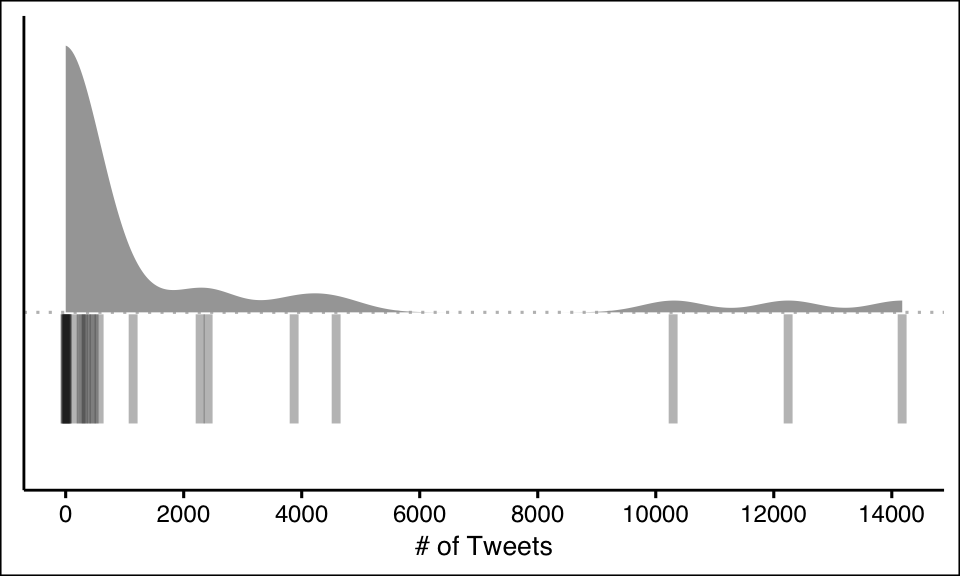

```r
df4 |>
  mutate(group = "gr") |> # just for plotting purpose
  ggplot(aes(x = group, y = x)) +
  stat_halfeye(.width = 0,
               point_colour = NA) +
  gghalves::geom_half_point(
    side = "b",
    shape = 124,       # draw horizontal lines instead of points
    range_scale = 0,   # remove jitter along x axis
    size = 15,
    alpha = .3
    )  +
  coord_flip() +
  theme_clean() +
  ylab("# of Tweets") +
  xlab(NULL) +
  theme(axis.text.y=element_blank(), axis.ticks.y=element_blank()) +
  scale_y_continuous(n.breaks = 10)
```

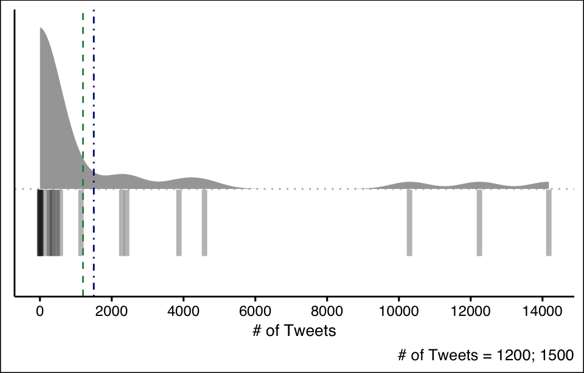

```r
df4 |>
  mutate(group = "gr") |> # just for plotting purpose
  ggplot(aes(x = group, y = x)) +
  stat_halfeye(.width = 0,
               point_colour = NA) +
  gghalves::geom_half_point(
    side = "b",
    shape = 124,       # draw horizontal lines instead of points
    range_scale = 0,   # remove jitter along x axis
    size = 15,
    alpha = .3
    )  +
  coord_flip() +
  theme_clean() +
  ylab("# of Tweets") +
  xlab(NULL) +
  theme(axis.text.y=element_blank(), axis.ticks.y=element_blank()) +
  scale_y_continuous(n.breaks = 10) +
  geom_hline(yintercept=1200, lty=2, color='seagreen') +
  geom_hline(yintercept=1500, lty=4, color='navy') +
  labs(caption = "# of Tweets = 1200; 1500")
```